# A Glimpse at Life Expectancies and Estimated Cancer Deaths

Sophie Shi

10/20/2019

```r
cancer <- read.csv("~/Downloads/cancerdeath.csv")
life <- read.csv("~/Downloads/life.csv")
head(cancer)
```

```
##      State Estimated.New.Cases..2019 Estimated.Deaths..2019.
## 1
## 2
## 3  Alabama                    28,950                  10,630
## 4   Alaska                     3,090                   1,120
## 5  Arizona                    37,490                  12,470
## 6 Arkansas                    16,580                   6,800
```

```r
head(life)
```

```
##         State Overall.Avg.. Black.Avg. Latino.Avg. Asian.Avg.
## 1      Hawaii          81.3       79.7        87.3       83.5
## 2   Minnesota          81.1       82.5        76.8         82
## 3 Connecticut          80.8       77.8        83.1       89.1
## 4  California          80.8       75.1        83.2       86.3
## 5     Vermont          80.5       84.4           -          -
## 6    New York          80.5       77.4        83.5       88.6
##   Native.American.Avg. White.Avg.
## 1                 70.2       81.2
## 2                    -       80.4
## 3                    -       81.0
## 4                 80.2       79.8
## 5                    -       80.4
## 6                    -       80.5
```

## Introduction

The first dataset from the American Cancer Society includes the estimated amount of new cases of cancer and cancer deaths of 2019 by state. This has 55 observations with three variables: State, New Cases, Deaths. These counts are from all cancer types.

The second dataset is from worldpopulationreview.com– it gives life expectancy by state as well as life expectancy by race. This dataset has 50 observations with 7 variables: State, Overall average life expectancy, Black average, Latino average, Asian average, Native American average, and Caucasian average in each of the states.

It will be interesting to see whether or not life expectancy have any impact on cancer related incidence or deaths by state. We would expect from investigation that states with higher life expectancies will have a lower amount of estimated new cancer cases or cancer deaths.

## Joining/Merging

```r
fulldata <- full_join(cancer, life, by="State")
fulldata <- fulldata %>%
  na.omit() %>%
  rename("Estimated New Cases" = Estimated.New.Cases..2019)%>%
  rename("Estimated Deaths" = Estimated.Deaths..2019.)%>%
  rename("Life Expectancy Overall (years)" = Overall.Avg..) %>%
  rename("Life Expectancy African American (years)" = Black.Avg.) %>%
  rename("Life Expectancy Latino (years)" = Latino.Avg.) %>%
  rename("Life Expectancy Asian (years)" = Asian.Avg.) %>%
  rename("Life Expectancy Native American (years)" = Native.American.Avg.) %>%
  rename("Life Expectancy Caucasian (years)" = White.Avg.)
head(data)
```

[output not shown]

Full data was used to combine these two datasets based on state. The states with unavailable statistics (NA) were omitted which resulted in losing 6 states from the cancer dataset, and 1 state from the life expectancy dataset. Columns were renamed so that they were easier to read. The resulting joined data has 49 observations and 9 variables.

## Tidying: Rearranging Wide/Long

```r
long <-fulldata %>%
  pivot_longer(c("Estimated New Cases", "Estimated Deaths"), names_to = "cancer", values_to = "counts")
long%>%select(cancer, counts)%>%head()
```

```
## # A tibble: 6 x 2
##   cancer              counts
##   <chr>               <fct>
## 1 Estimated New Cases 28,950
## 2 Estimated Deaths    10,630
## 3 Estimated New Cases 3,090
## 4 Estimated Deaths    1,120
## 5 Estimated New Cases 37,490
## 6 Estimated Deaths    12,470
```

```r
wide <- long%>% pivot_wider(names_from = cancer,
  values_from = "counts")
wide%>%select(`Estimated New Cases`,`Estimated Deaths`)%>%head()
```

```
## # A tibble: 6 x 2
##   `Estimated New Cases` `Estimated Deaths`
##   <fct>                 <fct>
## 1 28,950                10,630
## 2 3,090                 1,120
## 3 37,490                12,470
## 4 16,580                6,800
## 5 186,920               60,590
## 6 26,800                8,120
```

This data was already tidy, so pivot_longer was used to create a column that combined both variables estimated deaths and estimated new cases of cancer. We then used pivot_wider to tidy the data back to normal.

## Wrangling

```r
fulldata %>% filter( State == "Alabama")
```

```
##     State Estimated New Cases Estimated Deaths Life Expectancy Overall (years)
## 1 Alabama              28,950           10,630                            75.4
##   Life Expectancy African American (years) Life Expectancy Latino (years)
## 1                                     72.9                              -
##   Life Expectancy Asian (years) Life Expectancy Native American (years)
## 1                            76                                       -
##   Life Expectancy Caucasian (years)
## 1                                76
```

```r
fulldata%>%slice(1:4)%>%glimpse()
```

```
## Observations: 4
## Variables: 9
## $ State                                      <chr> "Alabama", "Alaska", "Ariz…
## $ `Estimated New Cases`                      <fct> "28,950", "3,090", "37,490…
## $ `Estimated Deaths`                         <fct> "10,630", "1,120", "12,470…
## $ `Life Expectancy Overall (years)`          <dbl> 75.4, 78.3, 79.6, 76.0
## $ `Life Expectancy African American (years)` <dbl> 72.9, 79.3, 76.5, 72.2
## $ `Life Expectancy Latino (years)`           <fct> -, -, 80.8, -
## $ `Life Expectancy Asian (years)`            <fct> 76, -, 86.7, -
## $ `Life Expectancy Native American (years)`  <fct> -, 70.5, 72.7, -
## $ `Life Expectancy Caucasian (years)`        <dbl> 76.0, 79.4, 79.8, 76.3
```

```r
fulldata %>% arrange((`Life Expectancy Overall (years)`))%>%glimpse()
```

```
## Observations: 49
## Variables: 9
## $ State                                      <chr> "Alabama", "West Virginia"…
## $ `Estimated New Cases`                      <fct> "28,950", "12,440", "26,80…
## $ `Estimated Deaths`                         <fct> "10,630", "4,820", "9,260"…
## $ `Life Expectancy Overall (years)`          <dbl> 75.4, 75.4, 75.7, 75.9, 76…
## $ `Life Expectancy African American (years)` <dbl> 72.9, 72.8, 72.4, 72.8, 72…
## $ `Life Expectancy Latino (years)`           <fct> -, -, -, 85, -, -, -, -, -…
## $ `Life Expectancy Asian (years)`            <fct> 76, -, 85.6, -, -, -, 84.2…
## $ `Life Expectancy Native American (years)`  <fct> -, -, -, 73.8, -, -, -, -,…
## $ `Life Expectancy Caucasian (years)`        <dbl> 76.0, 75.4, 76.7, 76.0, 76…
```

```r
fulldata %>% select(1,3,8)%>%glimpse()
```

```
## Observations: 49
## Variables: 3
## $ State                                     <chr> "Alabama", "Alaska", "Arizo…
## $ `Estimated Deaths`                        <fct> "10,630", "1,120", "12,470"…
## $ `Life Expectancy Native American (years)` <fct> -, 70.5, 72.7, -, 80.2, -, …
```

```r
fulldata %>% group_by(`Life Expectancy African American (years)`, `Life Expectancy Caucasian (years)`) %>% mutate(white_to_black= (`Life Expectancy Caucasian (years)`/`Life Expectancy African American (years)`))%>%select(white_to_black)%>%head()
```

[output not shown]

```
## # A tibble: 6 x 3
## # Groups:   Life Expectancy African American (years), Life Expectancy Caucasian
## #   (years) [6]
##   `Life Expectancy African American… `Life Expectancy Caucasian … white_to_black
##                                <dbl>                        <dbl>          <dbl>
## 1                               72.9                         76             1.04
## 2                               79.3                         79.4           1.00
## 3                               76.5                         79.8           1.04
## 4                               72.2                         76.3           1.06
## 5                               75.1                         79.8           1.06
## 6                               76.7                         80.2           1.05
```

```r
fulldata %>%
  summarize(mean_lifeAfr = mean(`Life Expectancy African American (years)`),
            sd_lifeAfr = sd(`Life Expectancy African American (years)`),
            min_lifeAfr=min(`Life Expectancy African American (years)`),
            max_lifeAfr = max(`Life Expectancy African American (years)`),
            IQR_lifeAfr=IQR(`Life Expectancy African American (years)`))
```

```
##   mean_lifeAfr sd_lifeAfr min_lifeAfr max_lifeAfr IQR_lifeAfr
## 1     76.50204   3.849161        71.6        86.8           4
```

```r
  fulldata%>% summarize(mean_lifeCau=mean(`Life Expectancy Caucasian (years)`),
            sd_lifeCau=sd(`Life Expectancy Caucasian (years)`),
            min_lifeCau=min(`Life Expectancy Caucasian (years)`),
            max_lifeCau=max(`Life Expectancy Caucasian (years)`),
            IQR_lifeCau=IQR(`Life Expectancy Caucasian (years)`))
```

```
##   mean_lifeCau sd_lifeCau min_lifeCau max_lifeCau IQR_lifeCau
## 1     78.88571   1.475071        75.4        81.2         2.1
```

This shows that the filter() function returns all of the variables corresponding with the only the state of Alabama.

Slice() function returns the first four rows and all of the columns (when organized alphabetically).

Select() was used to select columns 1, 3, and 8 of our data.

We added a variable of white to black ratio of each state, where we take the life expectancy of Caucasians and divide by life expectancies of African Americans for each state. At first glance, it seems like the majority of ratios are above one, meaning that the average life expectancy of caucasians in the majority of states is higher than African Americans.

When we calculate our summary statistics using summarize(), we see that African Americans have a mean life expectancy of 76.5 years with a standard deviation of 3.849 years, a minimum life expectancy of 71.6 years, maximum of 86.8 years, an IQR of 4 years.

These summary statistics were calculated because the other races had a lot of missing values. We see on average, African Americans have a lower mean life expectancy but a higher maximum life expectancy than Caucasian Americans. There is less variation from the mean life expectancy from Caucasian Americans as both the IQR and standard deviation are less than that of African Americans. African Americans also have a lower minimum life expectancy than Caucasian Americans. These summary statistics lead us to believe that African Americans have lower life expectancies than Caucasian Americans.

```r
fulldata %>%
  select_if(is.numeric) %>%
  cor()
```

```
##                                          Life Expectancy Overall (years)
## Life Expectancy Overall (years)                                1.0000000
## Life Expectancy African American (years)                       0.5106305
## Life Expectancy Caucasian (years)                              0.9547957
##                                          Life Expectancy African American (years)
## Life Expectancy Overall (years)                                         0.5106305
## Life Expectancy African American (years)                                1.0000000
## Life Expectancy Caucasian (years)                                       0.5157948
##                                          Life Expectancy Caucasian (years)
## Life Expectancy Overall (years)                                  0.9547957
## Life Expectancy African American (years)                         0.5157948
## Life Expectancy Caucasian (years)                                1.0000000
```

This correlation matrix shows how strongly different variables are related. This reveals that African American life expectancy has a moderate positive linear relationship (r=0.51) with overall life expectancy and caucasian life expectancy, whereas caucasian has a strong positive relationship with overall life expectancy with an r value of 0.95.

## Visualizing

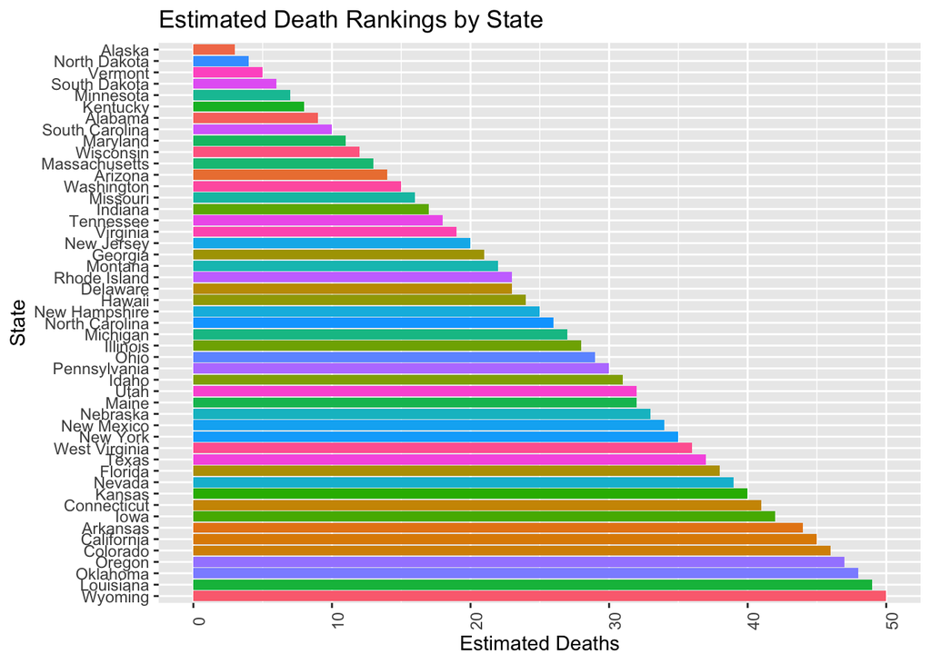

```r
fulldata$`Estimated Deaths` <- as.numeric(fulldata$`Estimated Deaths`)
mdata<-as.data.frame(fulldata)
mdata %>%
ggplot(aes(x = reorder(State, -`Estimated Deaths`),fill=State, `Estimated Deaths`)) +
geom_bar(stat = "summary", fun.y="mean")+
coord_flip() +theme(axis.text.x = element_text(angle = 90, hjust = 0.5)) +
  ggtitle("Estimated Death Rankings by State") +xlab("State")+theme(legend.position = "none")
```

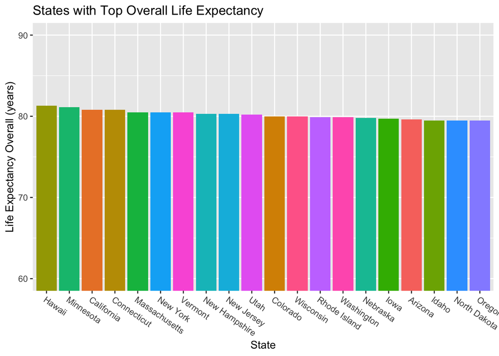

```r
top20life<-fulldata%>%arrange(desc(`Life Expectancy Overall (years)`))%>%slice(1:20)

top20life %>%
ggplot(aes(x = reorder(State, -`Life Expectancy Overall (years)`), fill=State, `Life Expectancy Overall (years)`)) +
geom_bar( stat = "summary", fun.y="mean")+
coord_flip() +theme(axis.text.x = element_text(angle = -35, hjust = 0)) +
  ggtitle("States with Top Overall Life Expectancy") + xlab("State") +theme(legend.position = "none")+coord_cartesian(ylim=c(60,90))
```

## Dimensionality Reduction

```r
library(cluster)

fulldata1<-fulldata%>%select_if(is.numeric)%>%scale

dataPCA<-princomp(fulldata1)

names(dataPCA)
```

```
## [1] "sdev"     "loadings" "center"   "scale"    "n.obs"    "scores"   "call"
```

```r
summary(dataPCA, loadings=T)
```

```
## Importance of components:
##                          Comp.1    Comp.2    Comp.3      Comp.4
## Standard deviation     1.532015 0.9864544 0.7479876 0.196771494
## Proportion of Variance 0.598992 0.2483412 0.1427853 0.009881417
## Cumulative Proportion  0.598992 0.8473332 0.9901186 1.000000000
##
## Loadings:
##                                          Comp.1 Comp.2 Comp.3 Comp.4
## Estimated Deaths                          0.186  0.935  0.293
## Life Expectancy Overall (years)          -0.603  0.264 -0.269 -0.703
## Life Expectancy African American (years) -0.477 -0.175  0.861
## Life Expectancy Caucasian (years)        -0.612  0.162 -0.318  0.706
```

```r
eigval<-dataPCA$sdev^2


varprop=round(eigval/sum(eigval),2) #proportion of var explained by each PC
round(cumsum(eigval)/sum(eigval),2)
```

```
## Comp.1 Comp.2 Comp.3 Comp.4
##   0.60   0.85   0.99   1.00
```

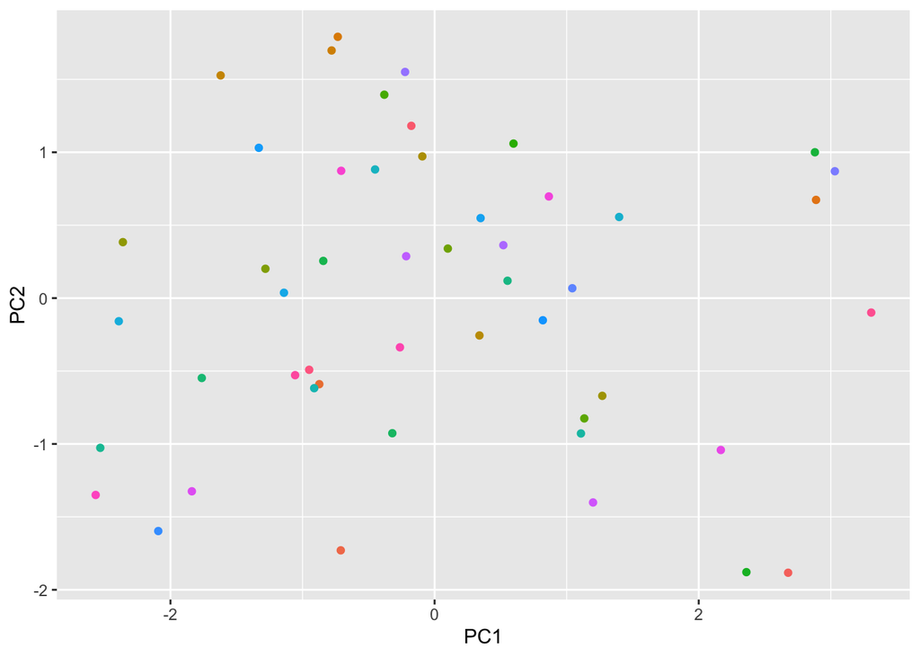

```r
State <-fulldata$State
fulldata%>%mutate(PC1=dataPCA$scores[,1], PC2=dataPCA$scores[,2])%>%
ggplot(aes(PC1,PC2,color=State))+geom_point(aes(dataPCA$scores[,1], dataPCA$scores[,2]))+xlab("PC1")+ylab("PC2")+
  theme(legend.position = "none") #plots data with respect to first two PC
```

```r
dataPCA$scores%>%as.data.frame%>%cbind(State,.)%>%top_n(3,Comp.1) #highest on PC1
```

```
##           State   Comp.1      Comp.2    Comp.3      Comp.4
## 1      Arkansas 2.888237  0.67344460 0.4397621  0.06320932
## 2      Oklahoma 3.030725  0.86990575 0.7410885 -0.01083435
## 3 West Virginia 3.306032 -0.09911034 0.6984557 -0.14547515
```

```r
dataPCA$scores%>%as.data.frame%>%cbind(State,.)%>%top_n(3,wt=desc(Comp.1)) #lowest on PC1
```

```
##           State    Comp.1     Comp.2    Comp.3      Comp.4
## 1     Minnesota -2.531537 -1.0266181 0.2035124 -0.41250045
## 2 New Hampshire -2.391277 -0.1584848 1.7505979 -0.08201638
## 3       Vermont -2.566491 -1.3496699 0.6874814 -0.15105255
```

```r
dataPCA$scores%>%as.data.frame%>%cbind(State,.)%>%top_n(3,wt=Comp.2) #highest on PC2
```

```
##        State     Comp.1   Comp.2      Comp.3      Comp.4
## 1 California -0.7331009 1.791775 -0.45852283 -0.37418787
## 2   Colorado -0.7798697 1.698031 -0.02967601  0.18368871
## 3     Oregon -0.2235693 1.550728  0.40373488 -0.06569669
```

```r
dataPCA$scores%>%as.data.frame%>%cbind(State,.)%>%top_n(3,wt=desc(Comp.2)) #lowest on PC2
```

```
##      State     Comp.1    Comp.2     Comp.3      Comp.4
## 1  Alabama  2.6769224 -1.882953 0.01406111 -0.01354353
## 2   Alaska -0.7105551 -1.729440 0.09276921  0.31621024
## 3 Kentucky  2.3609094 -1.878861 0.02504209 -0.28329825
```

Arkansas, Oklahoma and W. Virginia show the most variance on PC1. California, Colorado, and Oregon show the most variance on PC2. Data is scattered along both axes of PC1 and PC2; PC1 and PC2 do not seem to have any association with State.

```r
library(factoextra)
```

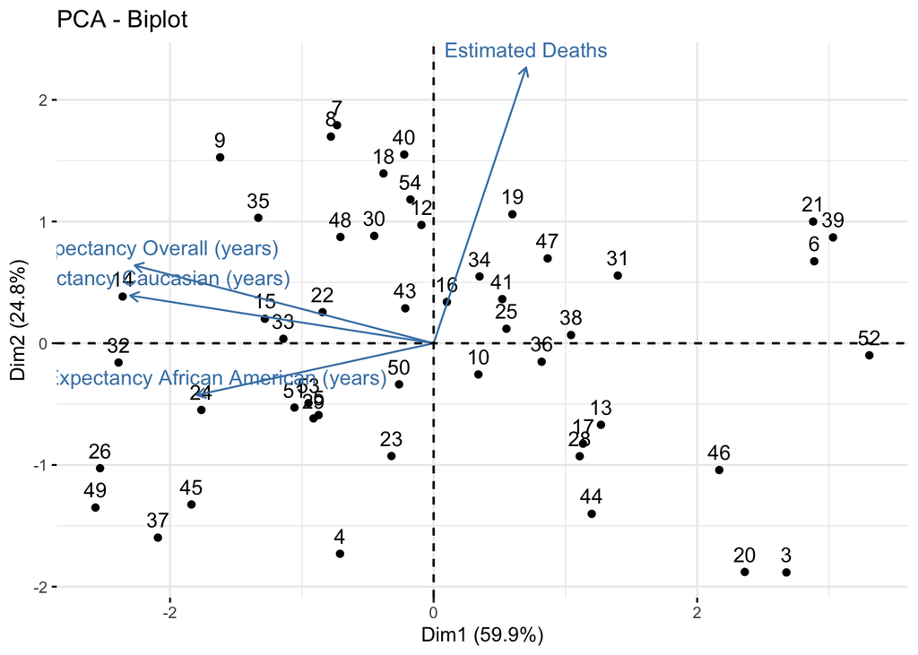

```r
fviz_pca_biplot(dataPCA)
```

From the biplot, see that Life Expectancy Overall and Life Expectancy of Caucasian Americans is strongly positively correlated as they are at a small angle away from one another in the biplot.

Life expectancy of African Americans is moderately positively correlated as it is pointing in the same direction but at a larger angle away from the other two variables.

Estimated Deaths seems to be slightly negatively correlated with the other variables.